[output not shown]

## Why Should We Care About Temperature Change?

First, we will import the CSV file. In most cases, we don’t need to preprocess the csv files.

```r
# Importing Scripts

file = "/home/CAMPUS/kaj41925/Climate_Change_Narratives/Khalil/NewOrleansNOAAdata.csv"

import = read.csv(file)
```

## Checking the Data(echo = False)

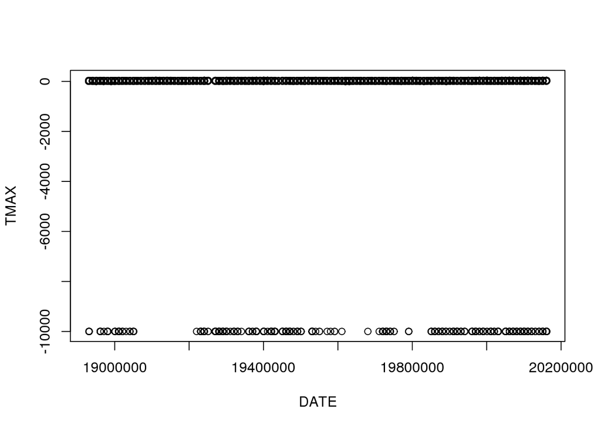

```r
plot(TMAX~DATE, import)
```

What’s going on? What is the deal with the -9999? These are used for missing data. We need to remove them!(echo = False)

Okay, now we’ll check again, for dates less then Dec. 31, 1913

[figure not shown]

```r
strDates <- as.character(import$DATE)
head(strDates)
```

```
## [1] "18930101" "18930102" "18930103" "18930104" "18930105" "18930106"
```

```r
import$NewDate <- as.Date(strDates, "%Y%m%d")
```

Yikes! What’s wrong? As it turns it the problem is that with how the dates are specified. In particular, the Dec 31 to Jan 1 transition

19131231 -> 19140101, if you use these as numbers it should be 19131232, 19131232, etc. You see we are missing lots numbers!

[figure not shown]

## Fixing the Dates

First, we convert the date a string or character values. Next, we’ll convert the strings to a data format.

## Subset Sites

```
## [1] NEW ORLEANS AUDUBON LA US
## Levels: NEW ORLEANS AUDUBON LA US
```

## A new plot

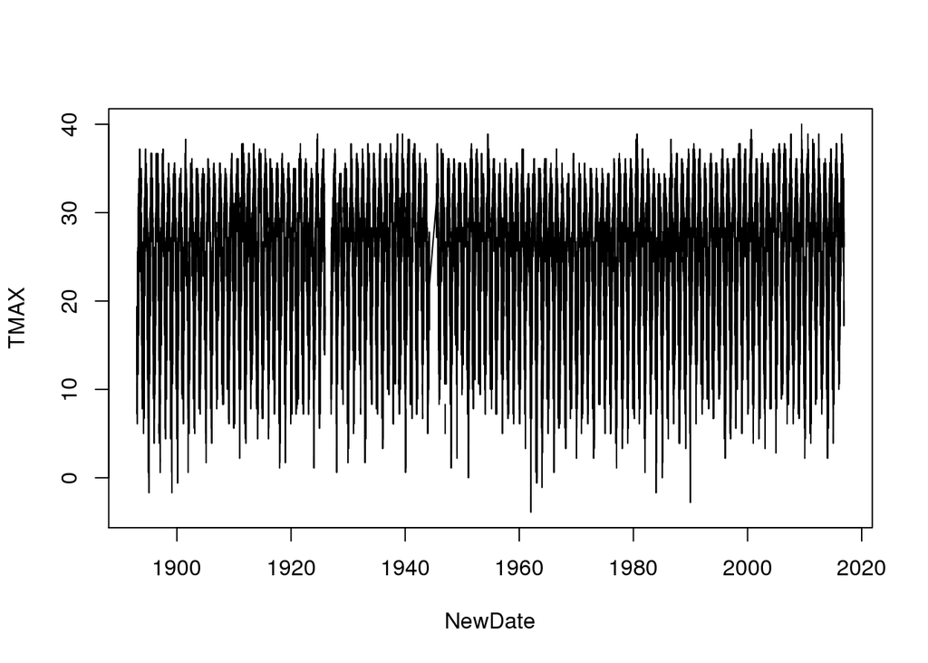

## Evaluating the trend

Creating a linear model and then evaluate the rate (slope).

```
##
## Call:
## lm(formula = TMAX ~ NewDate, data = LosAngeles)
##
## Residuals:
##     Min      1Q  Median      3Q     Max
## -30.033  -4.370   1.157   5.692  13.736
##
## Coefficients:
##              Estimate Std. Error t value Pr(>|t|)
## (Intercept) 2.616e+01  3.617e-02 723.208  < 2e-16 ***
## NewDate     7.539e-06  2.548e-06   2.959  0.00308 **
## ---
## Signif. codes:  0 '***' 0.001 '**' 0.01 '*' 0.05 '.' 0.1 ' ' 1
##
## Residual standard error: 6.932 on 43027 degrees of freedom
##   (1154 observations deleted due to missingness)
## Multiple R-squared:  0.0002035,  Adjusted R-squared:  0.0001803
## F-statistic: 8.758 on 1 and 43027 DF,  p-value: 0.003084
```

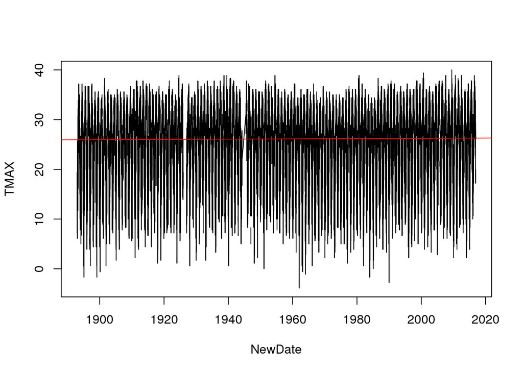

## Creating Month and Year Variables

So, let’s figure out how to see how changes happen for individual months.

### Creating Monthly Means

New Orleans is famous for its cuisine, authentic music, and culture, but most recently its been more famous for is temperature. 12 years ago Hurricane Katrina sobered us all, apprising us of the coming behemoth of Climate Change. Since then, the city has recovered, and is on the look out for future attacks from the surrounding oceans that will plague the birth place of jazz. However, New Orleans has overlooked a very prevalent danger that is non ocean based–temperature change. The city is known for its particularly warm and humid weather, but as of late we have been fried like frog legs by record breaking weather. Our ignorance of these spikes have made our underserved communities more vulnerable and as a region that is sensitive to climate change we must pay attention to these changes. The summer months have extended their stays, and dangerous heat has influenced moths that are known to be cooler. Our weather is changing and we have to change with it if we are to adapt to the quickly increasing temperatures.

### Selecting for 1 Month – June

Perhaps, we can can understand the temperature change in New Orleans if we analyze for just one month at a time! This is June

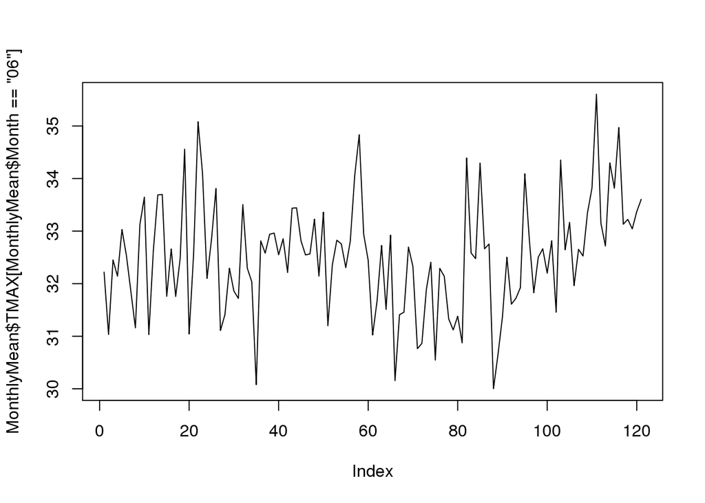

```r
plot(MonthlyMean$TMAX[MonthlyMean$Month=="06"], ty='l')
```

```r
plot(TMAX~YEAR, data=MonthlyMean[MonthlyMean$Month=="06",], ty='l')
May.lm <- lm(TMAX~YEAR, data=MonthlyMean[MonthlyMean$Month=="06",])
summary(May.lm)
```

```
##
## Call:
## lm(formula = TMAX ~ YEAR, data = MonthlyMean[MonthlyMean$Month ==
##     "06", ])
##
## Residuals:
##     Min      1Q  Median      3Q     Max
## -2.6171 -0.6783  0.0037  0.4919  2.8978
##
## Coefficients:
##              Estimate Std. Error t value Pr(>|t|)
## (Intercept) 25.278416   5.291573   4.777 5.12e-06 ***
## YEAR         0.003702   0.002706   1.368    0.174
## ---
## Signif. codes:  0 '***' 0.001 '**' 0.01 '*' 0.05 '.' 0.1 ' ' 1
##
## Residual standard error: 1.075 on 119 degrees of freedom
## Multiple R-squared:  0.01548,    Adjusted R-squared:  0.007211
## F-statistic: 1.872 on 1 and 119 DF,  p-value: 0.1739
```

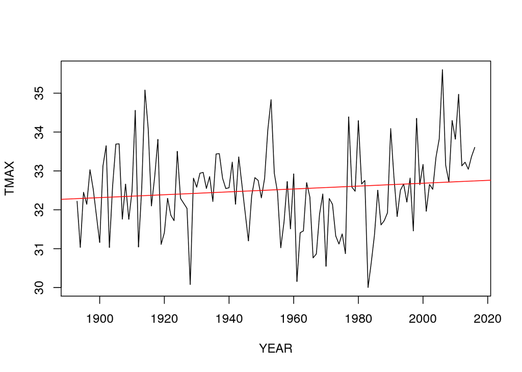

```r
abline(coef(May.lm), col="red")
```

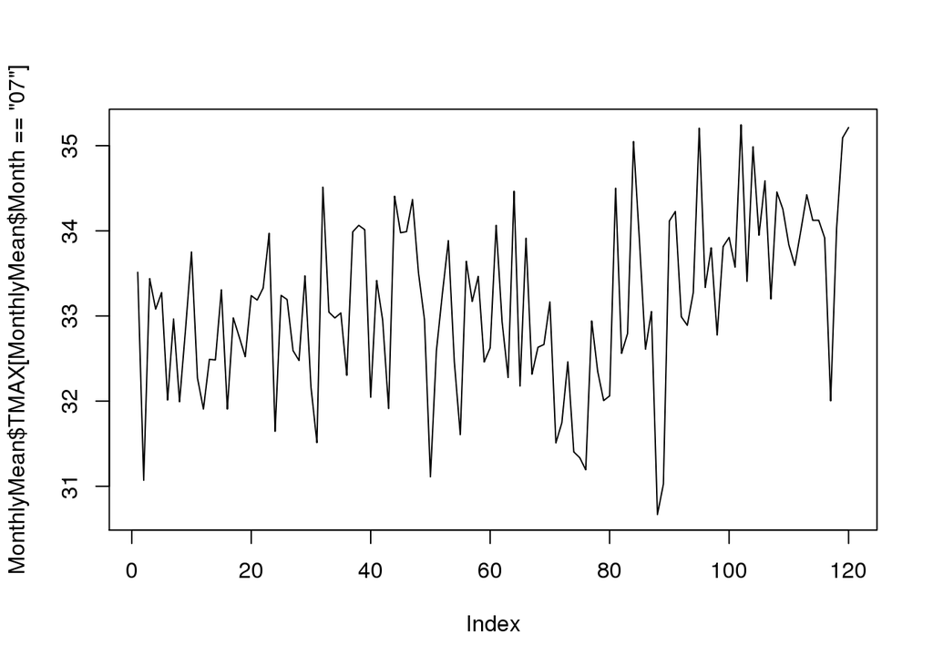

```r
plot(MonthlyMean$TMAX[MonthlyMean$Month=="07"], ty='l')
```

```r
plot(TMAX~YEAR, data=MonthlyMean[MonthlyMean$Month=="07",], ty='l')
May.lm <- lm(TMAX~YEAR, data=MonthlyMean[MonthlyMean$Month=="07",])
summary(May.lm)
```

```
##
## Call:
## lm(formula = TMAX ~ YEAR, data = MonthlyMean[MonthlyMean$Month ==
##     "07", ])
##
## Residuals:
##      Min       1Q   Median       3Q      Max
## -2.71738 -0.60994  0.09456  0.66450  1.75630
##
## Coefficients:
##              Estimate Std. Error t value Pr(>|t|)
## (Intercept) 15.290226   4.710914   3.246 0.001525 **
## YEAR         0.009120   0.002409   3.786 0.000243 ***
## ---
## Signif. codes:  0 '***' 0.001 '**' 0.01 '*' 0.05 '.' 0.1 ' ' 1
##
## Residual standard error: 0.9566 on 118 degrees of freedom
## Multiple R-squared:  0.1083, Adjusted R-squared:  0.1007
## F-statistic: 14.33 on 1 and 118 DF,  p-value: 0.0002427
```

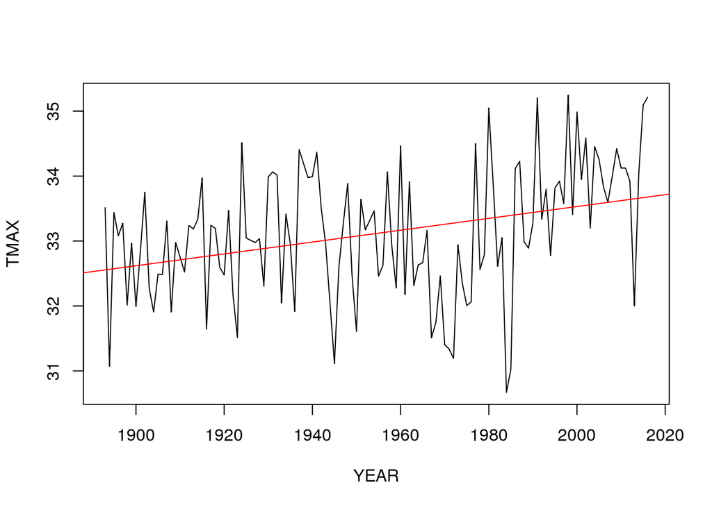

```r
abline(coef(May.lm), col="red")
```

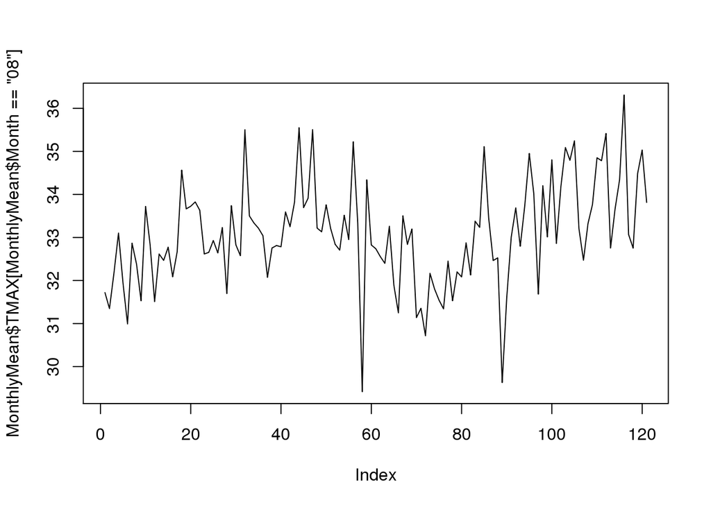

```r
plot(MonthlyMean$TMAX[MonthlyMean$Month=="08"], ty='l')
```

```r
plot(TMAX~YEAR, data=MonthlyMean[MonthlyMean$Month=="08",], ty='l')
May.lm <- lm(TMAX~YEAR, data=MonthlyMean[MonthlyMean$Month=="08",])
summary(May.lm)
```

```
##
## Call:
## lm(formula = TMAX ~ YEAR, data = MonthlyMean[MonthlyMean$Month ==
##     "08", ])
##
## Residuals:
##     Min      1Q  Median      3Q     Max
## -3.7088 -0.7040  0.0077  0.7291  2.7293
##
## Coefficients:
##              Estimate Std. Error t value Pr(>|t|)
## (Intercept) 15.493503   5.751326   2.694  0.00808 **
## YEAR         0.008994   0.002941   3.058  0.00275 **
## ---
## Signif. codes:  0 '***' 0.001 '**' 0.01 '*' 0.05 '.' 0.1 ' ' 1
##
## Residual standard error: 1.166 on 119 degrees of freedom
## Multiple R-squared:  0.07285,    Adjusted R-squared:  0.06506
## F-statistic: 9.351 on 1 and 119 DF,  p-value: 0.002754
```

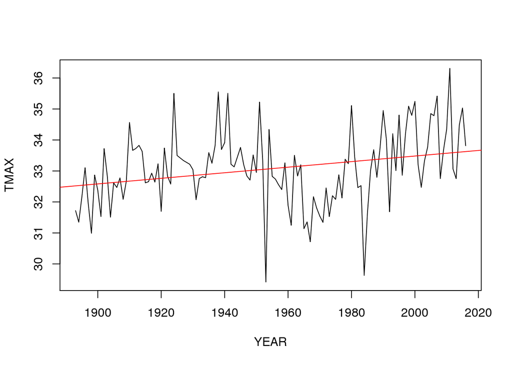

```r
abline(coef(May.lm), col="red")
```

August has a less dramatic incline, but still requires attention. This month saw a 25 day heatwave, that gave a bang to the end of the summer.

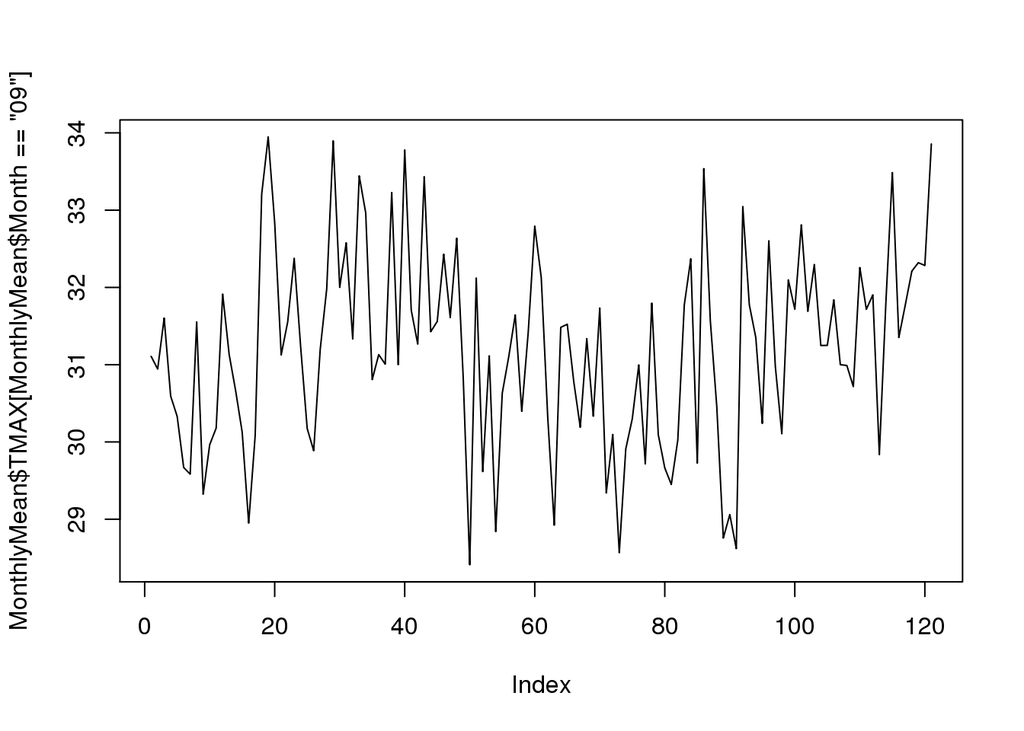

```r
plot(MonthlyMean$TMAX[MonthlyMean$Month=="09"], ty='l')
```

```r
plot(TMAX~YEAR, data=MonthlyMean[MonthlyMean$Month=="09",], ty='l')
May.lm <- lm(TMAX~YEAR, data=MonthlyMean[MonthlyMean$Month=="09",])
summary(May.lm)
```

```
##
## Call:
## lm(formula = TMAX ~ YEAR, data = MonthlyMean[MonthlyMean$Month ==
##     "09", ])
##
## Residuals:
##     Min      1Q  Median      3Q     Max
## -2.7705 -0.9406  0.0559  0.8331  2.8483
##
## Coefficients:
##              Estimate Std. Error t value Pr(>|t|)
## (Intercept) 26.152654   6.311315   4.144 6.42e-05 ***
## YEAR         0.002588   0.003229   0.802    0.424
## ---
## Signif. codes:  0 '***' 0.001 '**' 0.01 '*' 0.05 '.' 0.1 ' ' 1
##
## Residual standard error: 1.273 on 119 degrees of freedom
## Multiple R-squared:  0.00537,    Adjusted R-squared:  -0.002988
## F-statistic: 0.6425 on 1 and 119 DF,  p-value: 0.4244
```

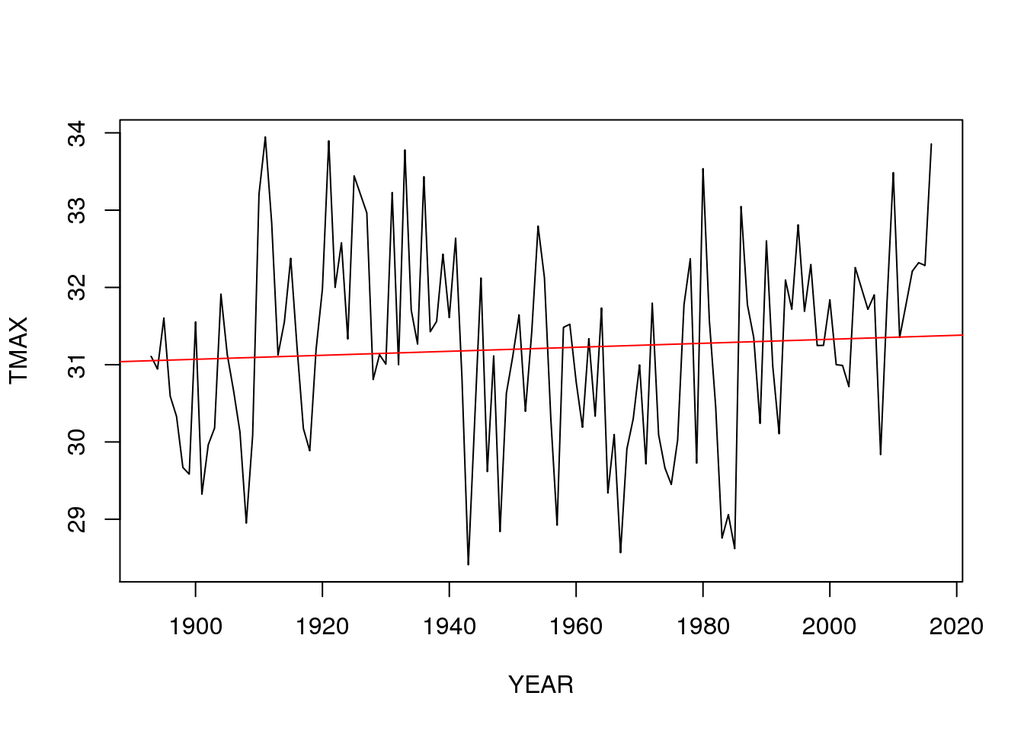

```r
abline(coef(May.lm), col="red")
```

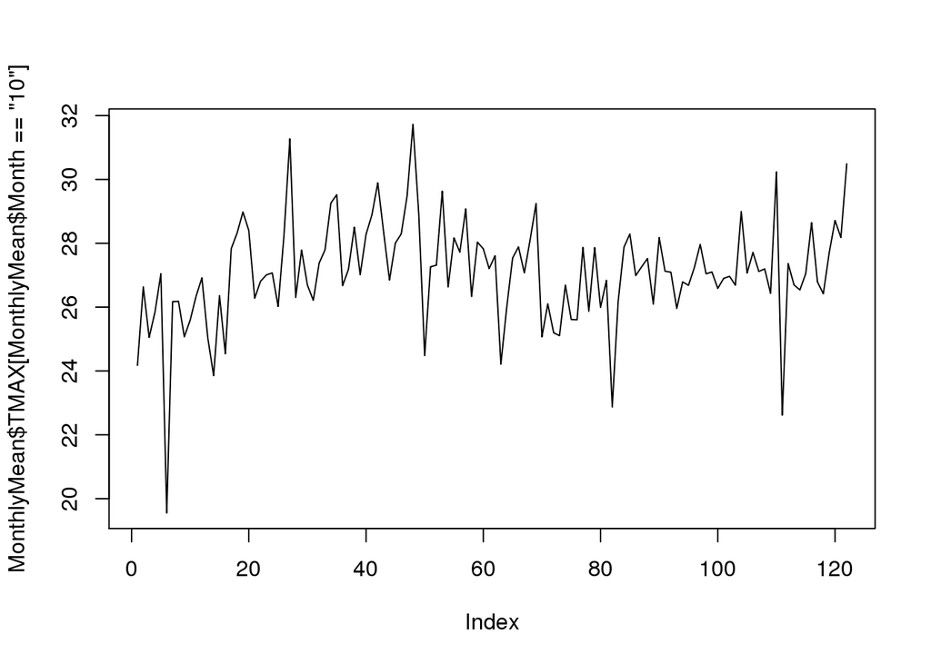

```r
plot(MonthlyMean$TMAX[MonthlyMean$Month=="10"], ty='l')
```

```r
plot(TMAX~YEAR, data=MonthlyMean[MonthlyMean$Month=="10",], ty='l')
May.lm <- lm(TMAX~YEAR, data=MonthlyMean[MonthlyMean$Month=="10",])
summary(May.lm)
```

```
##
## Call:
## lm(formula = TMAX ~ YEAR, data = MonthlyMean[MonthlyMean$Month ==
##     "10", ])
##
## Residuals:
##     Min      1Q  Median      3Q     Max
## -7.1768 -0.7259 -0.0672  0.9157  4.7269
##
## Coefficients:
##              Estimate Std. Error t value Pr(>|t|)
## (Intercept) 14.823604   8.079925   1.835    0.069 .
## YEAR         0.006271   0.004133   1.518    0.132
## ---
## Signif. codes:  0 '***' 0.001 '**' 0.01 '*' 0.05 '.' 0.1 ' ' 1
##
## Residual standard error: 1.642 on 120 degrees of freedom
## Multiple R-squared:  0.01883,    Adjusted R-squared:  0.01065
## F-statistic: 2.303 on 1 and 120 DF,  p-value: 0.1318
```

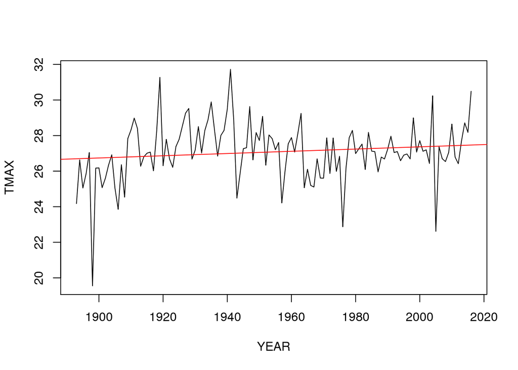

```r
abline(coef(May.lm), col="red")
```

This will have an enourmous impact on vulnerable communities. Eliot Kamenitz of The Times-Picayune details the drastic efforts that the city must take to protect underserved citizens from the heat.

Now, the change is 0.0062714 degress/year or 0.627 degress/100 years (YIKES!) with a probability of 0.1318. Although we can’t reject the null hypothesis, it is worrying!

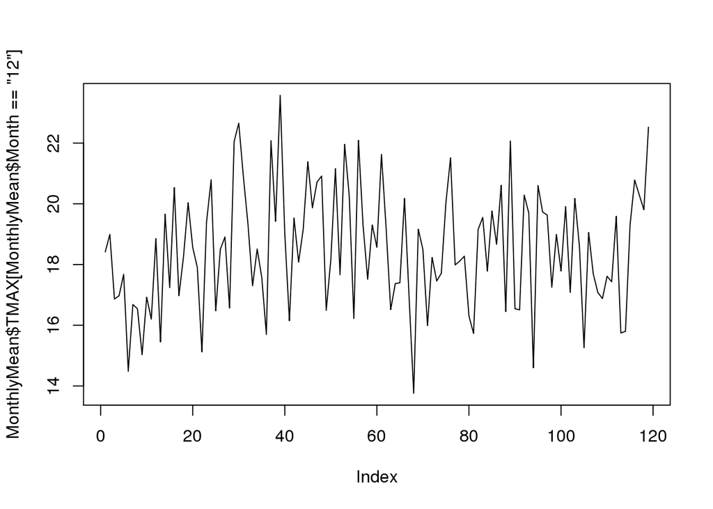

```
##
## Call:
## lm(formula = TMAX ~ YEAR, data = MonthlyMean[MonthlyMean$Month ==
##     "12", ])
##
## Residuals:
##     Min      1Q  Median      3Q     Max
## -4.7728 -1.3943  0.0562  1.1955  5.1660
##
## Coefficients:
##              Estimate Std. Error t value Pr(>|t|)
## (Intercept) 10.088843  10.013752   1.007    0.316
## YEAR         0.004302   0.005124   0.840    0.403
##
## Residual standard error: 1.988 on 117 degrees of freedom
## Multiple R-squared:  0.00599,    Adjusted R-squared:  -0.002506
## F-statistic: 0.7051 on 1 and 117 DF,  p-value: 0.4028
```

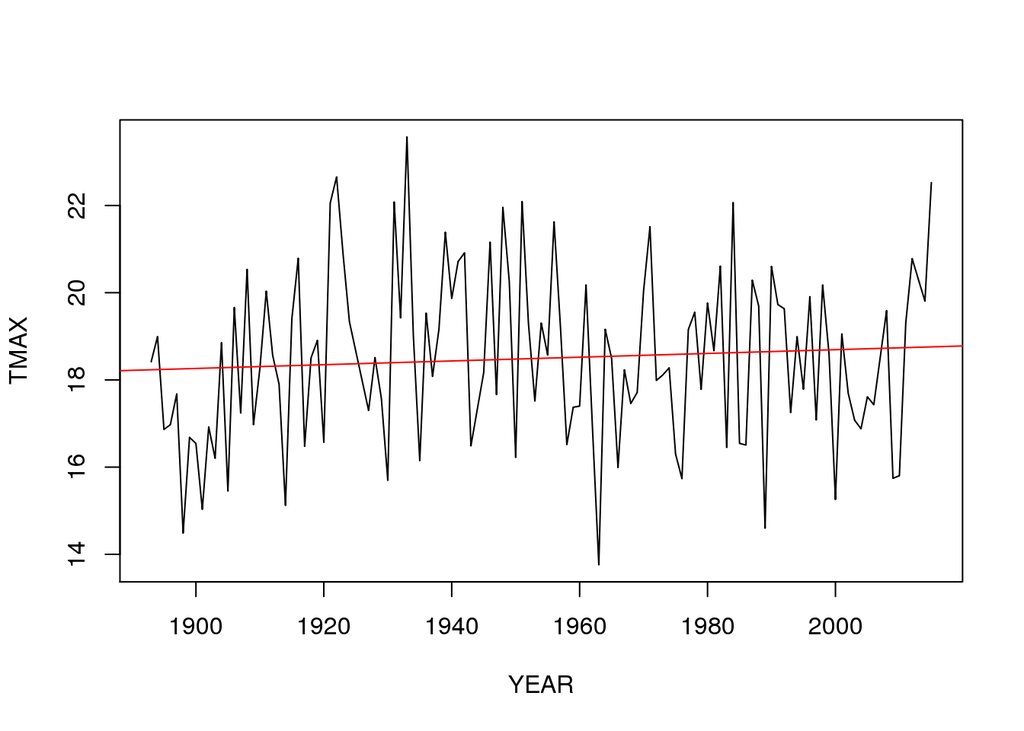

## TMIN

1. We create a monthly mean for each month.

```
##   Month Year      TMIN YEAR
## 1    01 1893  4.216129 1893
## 2    02 1893 12.389286 1893
## 3    03 1893  9.983871 1893
## 4    04 1893 16.289655 1893
## 5    05 1893 19.332258 1893
## 6    06 1893 22.280000 1893
```

2. Now we plot the mins, and again, find tons of scatter.

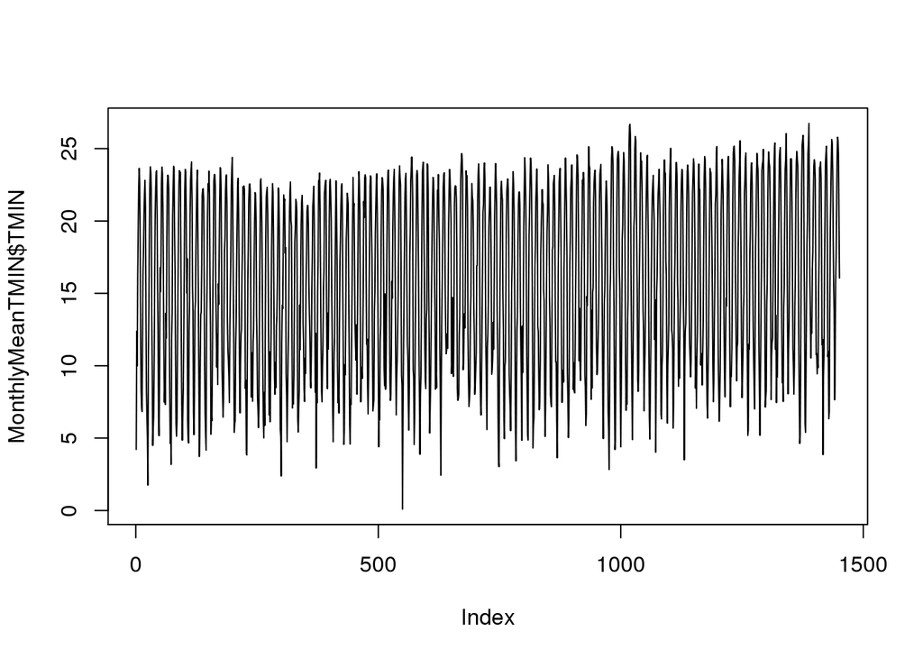

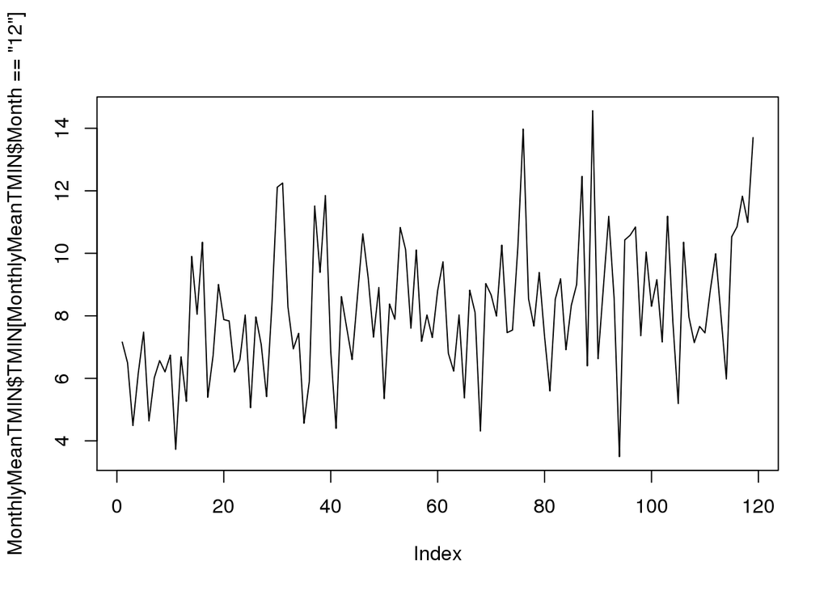

```
##
## Call:
## lm(formula = TMIN ~ YEAR, data = MonthlyMeanTMIN[MonthlyMeanTMIN$Month ==
##     "12", ])
##
## Residuals:
##     Min      1Q  Median      3Q     Max
## -5.4490 -1.2880 -0.1926  1.0409  5.7261
##
## Coefficients:
##               Estimate Std. Error t value Pr(>|t|)
## (Intercept) -35.039898  10.258092  -3.416 0.000875 ***
## YEAR          0.022114   0.005249   4.213 4.97e-05 ***
## ---
## Signif. codes:  0 '***' 0.001 '**' 0.01 '*' 0.05 '.' 0.1 ' ' 1
##
## Residual standard error: 2.036 on 117 degrees of freedom
## Multiple R-squared:  0.1317, Adjusted R-squared:  0.1243
## F-statistic: 17.75 on 1 and 117 DF,  p-value: 4.972e-05
```

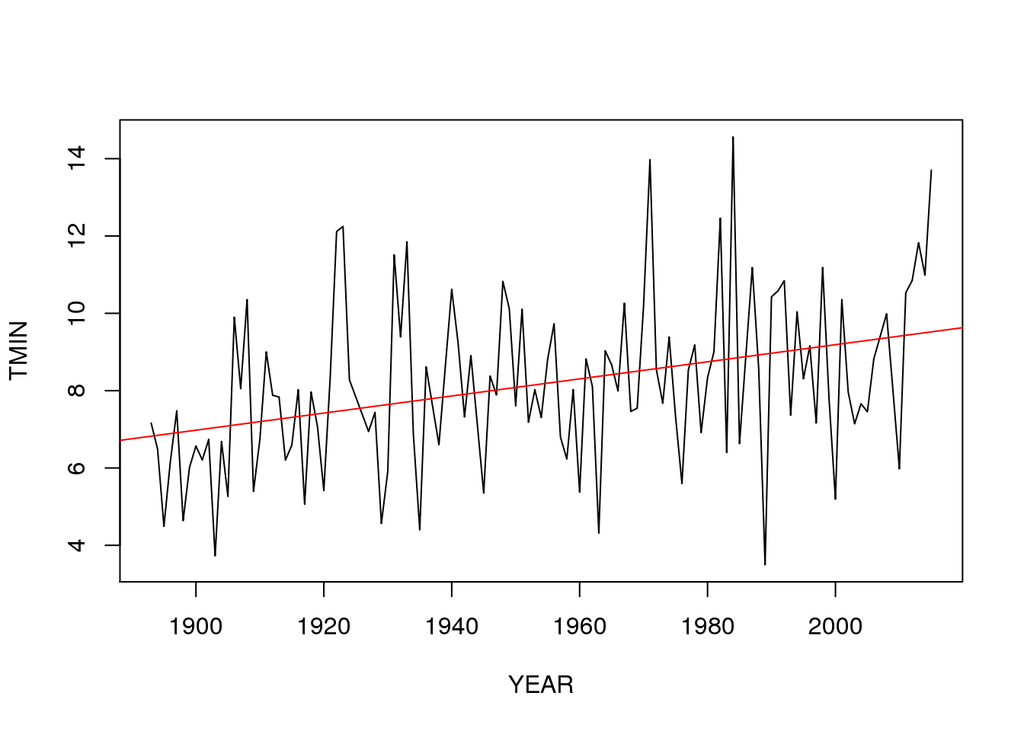

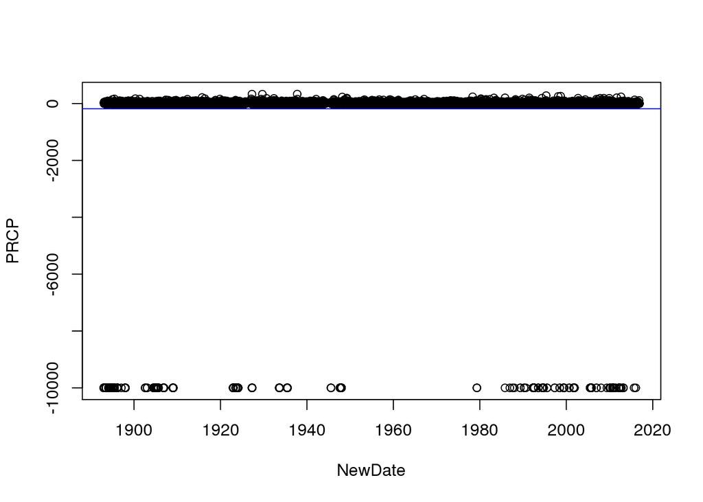

```
##
## Call:
## lm(formula = PRCP ~ YEAR, data = YearlySum)
##
## Residuals:
##      Min       1Q   Median       3Q      Max
## -1138.53  -242.13   -15.49   244.43  1280.79
##
## Coefficients:
##              Estimate Std. Error t value Pr(>|t|)
## (Intercept)  310.3891  1712.3277   0.181    0.856
## YEAR           0.6273     0.8758   0.716    0.475
##
## Residual standard error: 348.2 on 121 degrees of freedom
## Multiple R-squared:  0.004221,   Adjusted R-squared:  -0.004008
## F-statistic: 0.5129 on 1 and 121 DF,  p-value: 0.4752
```

Other attempts that didn’t work!

```
##  Time-Series [1:123, 1] from 1 to 123: 1426 1494 1858 1444 1349 ...
##  - attr(*, "dimnames")=List of 2
##   ..$ : NULL
##   ..$ : chr "PRCP"
```

yearlyts.lag = lag(yearlyts, 5)[6:112,]; head(yearlyts.lag)

plot(yearlyts, lty = 1, col = 3)

lines(yearlyts.lag)

lines(Departure ~ YEAR, data=YearlySum, col=“red”)